# Week 7 Lab: Unsupervised Learning

[figure not shown]

This week's assignment will focus completeing a K-Means analysis.

## Our Dataset:

**Dataset:** student-mat.csv(Provided in folder assign_wk7)

Remember to take a look at the student.txt files for a better understanding of the dataset. You can also read more about the dataset [here](https://archive.ics.uci.edu/ml/datasets/student+performance#)

## Unsupervised Lab

**Objective:**

- Use K-Means for this analysis
- Cluster the students to see if there are some natural groupings
- Use PCA to plot the clusters
- Discover any insights from this analysis? (include numbers/graphs corresponding to your reasoning)

**Things to keep in mind:**

- EDA!!! Explore your data!
- Does the dataset have missing values?
- What about categorical vs numeric columns in your dataset?
- Do you think you should normalize your data?

### Deliverables:

Upload your notebook's .ipynb file (This assignment can be done in one or two notebooks. The choice it up to you!)

**Important:** Make sure your provide complete and thorough explanations for all of your analysis. You need to defend your thought processes and reasoning.

```python
import pandas as pd
import numpy as np
import seaborn as sns

import matplotlib.pyplot as plt
%matplotlib inline

from sklearn.cluster import KMeans

sns.set()
```

```python
df =pd.read_csv('assign_wk7/student-mat.csv', low_memory=False, sep =';')
```

```python
df.head()
```

|  | school | sex | age | address | famsize | Pstatus | Medu | Fedu | Mjob | Fjob | ... | famrel | freetime | goout | Dalc | Walc | health | absences | G1 | G2 | G3 |
| --- | --- | --- | --- | --- | --- | --- | --- | --- | --- | --- | --- | --- | --- | --- | --- | --- | --- | --- | --- | --- | --- |
| 0 | GP | F | 18 | U | GT3 | A | 4 | 4 | at_home | teacher | ... | 4 | 3 | 4 | 1 | 1 | 3 | 6 | 5 | 6 | 6 |
| 1 | GP | F | 17 | U | GT3 | T | 1 | 1 | at_home | other | ... | 5 | 3 | 3 | 1 | 1 | 3 | 4 | 5 | 5 | 6 |
| 2 | GP | F | 15 | U | LE3 | T | 1 | 1 | at_home | other | ... | 4 | 3 | 2 | 2 | 3 | 3 | 10 | 7 | 8 | 10 |
| 3 | GP | F | 15 | U | GT3 | T | 4 | 2 | health | services | ... | 3 | 2 | 2 | 1 | 1 | 5 | 2 | 15 | 14 | 15 |
| 4 | GP | F | 16 | U | GT3 | T | 3 | 3 | other | other | ... | 4 | 3 | 2 | 1 | 2 | 5 | 4 | 6 | 10 | 10 |

5 rows × 33 columns

```python
df.info()
```

```
<class 'pandas.core.frame.DataFrame'>
RangeIndex: 395 entries, 0 to 394
Data columns (total 33 columns):
 #   Column      Non-Null Count  Dtype
---  ------      --------------  -----
 0   school      395 non-null    object
 1   sex         395 non-null    object
 2   age         395 non-null    int64
 3   address     395 non-null    object
 4   famsize     395 non-null    object
 5   Pstatus     395 non-null    object
 6   Medu        395 non-null    int64
 7   Fedu        395 non-null    int64
 8   Mjob        395 non-null    object
 9   Fjob        395 non-null    object
```

[output cut: 25 more lines]

```python
df.isnull().sum()
```

```
school        0
sex           0
age           0
address       0
famsize       0
Pstatus       0
Medu          0
Fedu          0
Mjob          0
Fjob          0
reason        0
guardian      0
traveltime    0
studytime     0
failures      0
schoolsup     0
famsup        0
paid          0
activities    0
nursery       0
higher        0
internet      0
romantic      0
famrel        0
freetime      0
goout         0
Dalc          0
Walc          0
health        0
absences      0
G1            0
G2            0
G3            0
dtype: int64
```

```python
df.nunique()
```

```
school         2
sex            2
age            8
address        2
famsize        2
Pstatus        2
Medu           5
Fedu           5
Mjob           5
Fjob           5
reason         4
guardian       3
traveltime     4
studytime      4
failures       4
schoolsup      2
famsup         2
paid           2
activities     2
nursery        2
higher         2
internet       2
romantic       2
famrel         5
freetime       5
goout          5
Dalc           5
Walc           5
health         5
absences      34
G1            17
G2            17
G3            18
dtype: int64
```

```python
df.age.unique()
```

```
array([18, 17, 15, 16, 19, 22, 20, 21], dtype=int64)
```

After a little EDA, there seems to be no null values at first glance, though I am still mildly suspicious given the previous datasets in this course. We will read the txt file for clues, and break down our columns into categories. We will also look to encode our dataset for the ML model. UPDATE we are not doing this, as we will eventually have to have all integers for our ML models. Looking back, the providers of the data did much of the work for us in encoding these categories already. My category calls will be commented out.

```python
df
```

|  | school | sex | age | address | famsize | Pstatus | Medu | Fedu | Mjob | Fjob | ... | famrel | freetime | goout | Dalc | Walc | health | absences | G1 | G2 | G3 |
| --- | --- | --- | --- | --- | --- | --- | --- | --- | --- | --- | --- | --- | --- | --- | --- | --- | --- | --- | --- | --- | --- |
| 0 | GP | F | 18 | U | GT3 | A | 4 | 4 | at_home | teacher | ... | 4 | 3 | 4 | 1 | 1 | 3 | 6 | 5 | 6 | 6 |
| 1 | GP | F | 17 | U | GT3 | T | 1 | 1 | at_home | other | ... | 5 | 3 | 3 | 1 | 1 | 3 | 4 | 5 | 5 | 6 |
| 2 | GP | F | 15 | U | LE3 | T | 1 | 1 | at_home | other | ... | 4 | 3 | 2 | 2 | 3 | 3 | 10 | 7 | 8 | 10 |
| 3 | GP | F | 15 | U | GT3 | T | 4 | 2 | health | services | ... | 3 | 2 | 2 | 1 | 1 | 5 | 2 | 15 | 14 | 15 |
| 4 | GP | F | 16 | U | GT3 | T | 3 | 3 | other | other | ... | 4 | 3 | 2 | 1 | 2 | 5 | 4 | 6 | 10 | 10 |
| ... | ... | ... | ... | ... | ... | ... | ... | ... | ... | ... | ... | ... | ... | ... | ... | ... | ... | ... | ... | ... | ... |
| 390 | MS | M | 20 | U | LE3 | A | 2 | 2 | services | services | ... | 5 | 5 | 4 | 4 | 5 | 4 | 11 | 9 | 9 | 9 |
| 391 | MS | M | 17 | U | LE3 | T | 3 | 1 | services | services | ... | 2 | 4 | 5 | 3 | 4 | 2 | 3 | 14 | 16 | 16 |
| 392 | MS | M | 21 | R | GT3 | T | 1 | 1 | other | other | ... | 5 | 5 | 3 | 3 | 3 | 3 | 3 | 10 | 8 | 7 |
| 393 | MS | M | 18 | R | LE3 | T | 3 | 2 | services | other | ... | 4 | 4 | 1 | 3 | 4 | 5 | 0 | 11 | 12 | 10 |
| 394 | MS | M | 19 | U | LE3 | T | 1 | 1 | other | at_home | ... | 3 | 2 | 3 | 3 | 3 | 5 | 5 | 8 | 9 | 9 |

395 rows × 33 columns

```python
##df[].apply(lambda x: x.astype('category'))

#cat_cols = ['school','sex','age','address','famsize','Pstatus','Medu','Fedu','Mjob','Fjob',
 #   'reason','guardian','traveltime','studytime','failures','schoolsup','famsup','paid','activities','nursery','higher',
  # 'internet','romantic','famrel','freetime','goout','Dalc','Walc','health']
#df[cat_cols] = df[cat_cols].astype('category')
```

```python
df.info()
```

```
<class 'pandas.core.frame.DataFrame'>
RangeIndex: 395 entries, 0 to 394
Data columns (total 33 columns):
 #   Column      Non-Null Count  Dtype
---  ------      --------------  -----
 0   school      395 non-null    object
 1   sex         395 non-null    object
 2   age         395 non-null    int64
 3   address     395 non-null    object
 4   famsize     395 non-null    object
 5   Pstatus     395 non-null    object
 6   Medu        395 non-null    int64
 7   Fedu        395 non-null    int64
 8   Mjob        395 non-null    object
 9   Fjob        395 non-null    object
```

[output cut: 25 more lines]

```python
df.corr()
```

|  | age | Medu | Fedu | traveltime | studytime | failures | famrel | freetime | goout | Dalc | Walc | health | absences | G1 | G2 | G3 |
| --- | --- | --- | --- | --- | --- | --- | --- | --- | --- | --- | --- | --- | --- | --- | --- | --- |
| age | 1.000000 | -0.163658 | -0.163438 | 0.070641 | -0.004140 | 0.243665 | 0.053940 | 0.016434 | 0.126964 | 0.131125 | 0.117276 | -0.062187 | 0.175230 | -0.064081 | -0.143474 | -0.161579 |
| Medu | -0.163658 | 1.000000 | 0.623455 | -0.171639 | 0.064944 | -0.236680 | -0.003914 | 0.030891 | 0.064094 | 0.019834 | -0.047123 | -0.046878 | 0.100285 | 0.205341 | 0.215527 | 0.217147 |
| Fedu | -0.163438 | 0.623455 | 1.000000 | -0.158194 | -0.009175 | -0.250408 | -0.001370 | -0.012846 | 0.043105 | 0.002386 | -0.012631 | 0.014742 | 0.024473 | 0.190270 | 0.164893 | 0.152457 |
| traveltime | 0.070641 | -0.171639 | -0.158194 | 1.000000 | -0.100909 | 0.092239 | -0.016808 | -0.017025 | 0.028540 | 0.138325 | 0.134116 | 0.007501 | -0.012944 | -0.093040 | -0.153198 | -0.117142 |
| studytime | -0.004140 | 0.064944 | -0.009175 | -0.100909 | 1.000000 | -0.173563 | 0.039731 | -0.143198 | -0.063904 | -0.196019 | -0.253785 | -0.075616 | -0.062700 | 0.160612 | 0.135880 | 0.097820 |
| failures | 0.243665 | -0.236680 | -0.250408 | 0.092239 | -0.173563 | 1.000000 | -0.044337 | 0.091987 | 0.124561 | 0.136047 | 0.141962 | 0.065827 | 0.063726 | -0.354718 | -0.355896 | -0.360415 |
| famrel | 0.053940 | -0.003914 | -0.001370 | -0.016808 | 0.039731 | -0.044337 | 1.000000 | 0.150701 | 0.064568 | -0.077594 | -0.113397 | 0.094056 | -0.044354 | 0.022168 | -0.018281 | 0.051363 |
| freetime | 0.016434 | 0.030891 | -0.012846 | -0.017025 | -0.143198 | 0.091987 | 0.150701 | 1.000000 | 0.285019 | 0.209001 | 0.147822 | 0.075733 | -0.058078 | 0.012613 | -0.013777 | 0.011307 |
| goout | 0.126964 | 0.064094 | 0.043105 | 0.028540 | -0.063904 | 0.124561 | 0.064568 | 0.285019 | 1.000000 | 0.266994 | 0.420386 | -0.009577 | 0.044302 | -0.149104 | -0.162250 | -0.132791 |
| Dalc | 0.131125 | 0.019834 | 0.002386 | 0.138325 | -0.196019 | 0.136047 | -0.077594 | 0.209001 | 0.266994 | 1.000000 | 0.647544 | 0.077180 | 0.111908 | -0.094159 | -0.064120 | -0.054660 |
| Walc | 0.117276 | -0.047123 | -0.012631 | 0.134116 | -0.253785 | 0.141962 | -0.113397 | 0.147822 | 0.420386 | 0.647544 | 1.000000 | 0.092476 | 0.136291 | -0.126179 | -0.084927 | -0.051939 |
| health | -0.062187 | -0.046878 | 0.014742 | 0.007501 | -0.075616 | 0.065827 | 0.094056 | 0.075733 | -0.009577 | 0.077180 | 0.092476 | 1.000000 | -0.029937 | -0.073172 | -0.097720 | -0.061335 |
| absences | 0.175230 | 0.100285 | 0.024473 | -0.012944 | -0.062700 | 0.063726 | -0.044354 | -0.058078 | 0.044302 | 0.111908 | 0.136291 | -0.029937 | 1.000000 | -0.031003 | -0.031777 | 0.034247 |
| G1 | -0.064081 | 0.205341 | 0.190270 | -0.093040 | 0.160612 | -0.354718 | 0.022168 | 0.012613 | -0.149104 | -0.094159 | -0.126179 | -0.073172 | -0.031003 | 1.000000 | 0.852118 | 0.801468 |
| G2 | -0.143474 | 0.215527 | 0.164893 | -0.153198 | 0.135880 | -0.355896 | -0.018281 | -0.013777 | -0.162250 | -0.064120 | -0.084927 | -0.097720 | -0.031777 | 0.852118 | 1.000000 | 0.904868 |
| G3 | -0.161579 | 0.217147 | 0.152457 | -0.117142 | 0.097820 | -0.360415 | 0.051363 | 0.011307 | -0.132791 | -0.054660 | -0.051939 | -0.061335 | 0.034247 | 0.801468 | 0.904868 | 1.000000 |

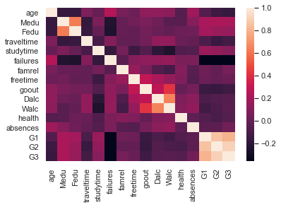

```python
_ = sns.heatmap(df.corr())
```

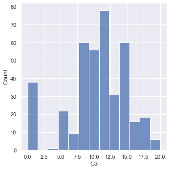

```python
sns.displot(data=df, x="G3",multiple="stack")
```

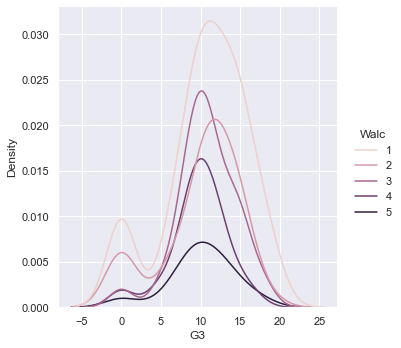

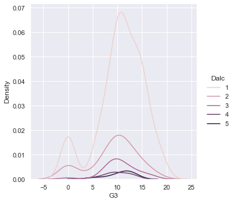

```python
sns.displot(data=df, x="G3",hue='Walc',kind='kde')
sns.displot(data=df, x='G3',hue='Dalc',kind='kde')
```

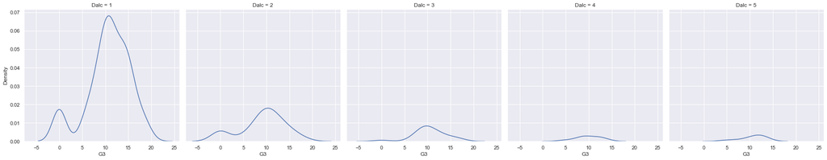

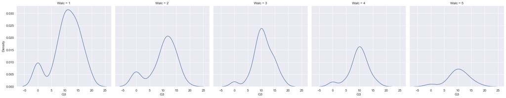

```python
sns.displot(data=df,x = 'G3', col = 'Dalc',kind = 'kde')
sns.displot(data=df,x = 'G3', col = 'Walc',kind = 'kde')
#Comparing impacts of Dalc (Workday alcohol consumption) & Walc (Weekend alcohol consumption)
```

## Reasoning for so many categorical

While many of the columns were integers, upon inspection of what they contain, both in Python and the Txt file, the vast majority of the integers were still categorical.

## Update - This is no longer true, leaving to show progress

See above markdown comment for more (all category calls were commented out. We will now encode our dataframe to then plug into our models.

```python
df.info()
```

```
<class 'pandas.core.frame.DataFrame'>
RangeIndex: 395 entries, 0 to 394
Data columns (total 33 columns):
 #   Column      Non-Null Count  Dtype
---  ------      --------------  -----
 0   school      395 non-null    object
 1   sex         395 non-null    object
 2   age         395 non-null    int64
 3   address     395 non-null    object
 4   famsize     395 non-null    object
 5   Pstatus     395 non-null    object
 6   Medu        395 non-null    int64
 7   Fedu        395 non-null    int64
 8   Mjob        395 non-null    object
 9   Fjob        395 non-null    object
```

[output cut: 25 more lines]

```python
needs_enc=['school','sex','address','famsize','Pstatus','Mjob','Fjob','reason','guardian','schoolsup','famsup',
          'paid','activities','nursery','higher','internet','romantic']
```

```python
df_encoded = pd.get_dummies(df, columns=needs_enc,
                            prefix=needs_enc)
```

```python
df_encoded
```

|  | age | Medu | Fedu | traveltime | studytime | failures | famrel | freetime | goout | Dalc | ... | activities_no | activities_yes | nursery_no | nursery_yes | higher_no | higher_yes | internet_no | internet_yes | romantic_no | romantic_yes |
| --- | --- | --- | --- | --- | --- | --- | --- | --- | --- | --- | --- | --- | --- | --- | --- | --- | --- | --- | --- | --- | --- |
| 0 | 18 | 4 | 4 | 2 | 2 | 0 | 4 | 3 | 4 | 1 | ... | 1 | 0 | 0 | 1 | 0 | 1 | 1 | 0 | 1 | 0 |
| 1 | 17 | 1 | 1 | 1 | 2 | 0 | 5 | 3 | 3 | 1 | ... | 1 | 0 | 1 | 0 | 0 | 1 | 0 | 1 | 1 | 0 |
| 2 | 15 | 1 | 1 | 1 | 2 | 3 | 4 | 3 | 2 | 2 | ... | 1 | 0 | 0 | 1 | 0 | 1 | 0 | 1 | 1 | 0 |
| 3 | 15 | 4 | 2 | 1 | 3 | 0 | 3 | 2 | 2 | 1 | ... | 0 | 1 | 0 | 1 | 0 | 1 | 0 | 1 | 0 | 1 |
| 4 | 16 | 3 | 3 | 1 | 2 | 0 | 4 | 3 | 2 | 1 | ... | 1 | 0 | 0 | 1 | 0 | 1 | 1 | 0 | 1 | 0 |
| ... | ... | ... | ... | ... | ... | ... | ... | ... | ... | ... | ... | ... | ... | ... | ... | ... | ... | ... | ... | ... | ... |
| 390 | 20 | 2 | 2 | 1 | 2 | 2 | 5 | 5 | 4 | 4 | ... | 1 | 0 | 0 | 1 | 0 | 1 | 1 | 0 | 1 | 0 |
| 391 | 17 | 3 | 1 | 2 | 1 | 0 | 2 | 4 | 5 | 3 | ... | 1 | 0 | 1 | 0 | 0 | 1 | 0 | 1 | 1 | 0 |
| 392 | 21 | 1 | 1 | 1 | 1 | 3 | 5 | 5 | 3 | 3 | ... | 1 | 0 | 1 | 0 | 0 | 1 | 1 | 0 | 1 | 0 |
| 393 | 18 | 3 | 2 | 3 | 1 | 0 | 4 | 4 | 1 | 3 | ... | 1 | 0 | 1 | 0 | 0 | 1 | 0 | 1 | 1 | 0 |
| 394 | 19 | 1 | 1 | 1 | 1 | 0 | 3 | 2 | 3 | 3 | ... | 1 | 0 | 0 | 1 | 0 | 1 | 0 | 1 | 1 | 0 |

395 rows × 59 columns

```python
df_encoded.info()
```

```
<class 'pandas.core.frame.DataFrame'>
RangeIndex: 395 entries, 0 to 394
Data columns (total 59 columns):
 #   Column             Non-Null Count  Dtype
---  ------             --------------  -----
 0   age                395 non-null    int64
 1   Medu               395 non-null    int64
 2   Fedu               395 non-null    int64
 3   traveltime         395 non-null    int64
 4   studytime          395 non-null    int64
 5   failures           395 non-null    int64
 6   famrel             395 non-null    int64
 7   freetime           395 non-null    int64
 8   goout              395 non-null    int64
 9   Dalc               395 non-null    int64
```

[output cut: 51 more lines]

```python
X = df_encoded.iloc[:,df_encoded.columns != 'G3']
y = df_encoded.iloc[:,df_encoded.columns == 'G3']
```

```python
from sklearn.cluster import KMeans
```

```python
sum_sq= []


for n in range (2,30):
    print('Calculating for ',n,' clusters')

    # random_start makes the results reproducible
    # n_jobs=-1 means run with all machine processors
    model = KMeans(n_clusters=n, random_state=42, n_jobs=-1)
    model.fit(X)
    sum_sq.append(-model.score(X))
```

```
Calculating for  2  clusters
Calculating for  3  clusters
Calculating for  4  clusters
Calculating for  5  clusters
Calculating for
```

```
 6  clusters
Calculating for  7  clusters
Calculating for  8  clusters
Calculating for  9  clusters
```

```
Calculating for  10  clusters
Calculating for  11  clusters
```

```
Calculating for  12  clusters
Calculating for  13  clusters
```

```
Calculating for  14  clusters
Calculating for  15  clusters
```

```
Calculating for  16  clusters
Calculating for  17  clusters
```

```
Calculating for  18  clusters
Calculating for  19  clusters
```

```
Calculating for  20  clusters
Calculating for  21  clusters
```

```
Calculating for  22  clusters
Calculating for  23  clusters
```

```
Calculating for  24  clusters
Calculating for  25  clusters
```

```
Calculating for  26  clusters
Calculating for
```

```
 27  clusters
Calculating for  28  clusters
```

```
C:\Users\musta\anaconda3\lib\site-packages\sklearn\cluster\_kmeans.py:938: FutureWarning: 'n_jobs' was deprecated in version 0.23 and will be removed in 0.25.
  warnings.warn("'n_jobs' was deprecated in version 0.23 and will be"
```

```
Calculating for  29  clusters
```

```
C:\Users\musta\anaconda3\lib\site-packages\sklearn\cluster\_kmeans.py:938: FutureWarning: 'n_jobs' was deprecated in version 0.23 and will be removed in 0.25.
  warnings.warn("'n_jobs' was deprecated in version 0.23 and will be"
```

Not entirely sure what these warnings are about, can likely find info on sklearn's site about new parameter, guessing 'jobs' or something, but moving on. We will now try and find our best k in the 'elbow'.

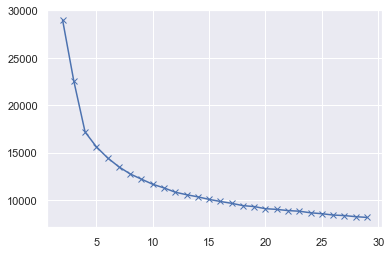

```python
plt.plot(range(2, 30), sum_sq, 'bx-')
```

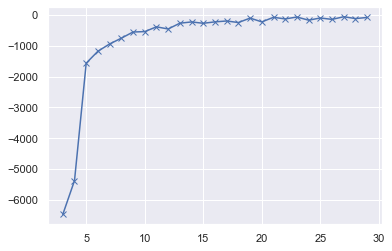

```python
plt.plot(range(3, 30), np.diff(sum_sq), 'bx-')
```

At quick glancce, we see our last real improvement at what looks like 13. Let's keep going.

```python
model = KMeans(n_clusters=13, random_state=42, n_jobs=-1)
model.fit(X)
preds= model.predict(X)
```

```python
from sklearn import metrics
score = metrics.silhouette_score(X, preds)
score
```

```
0.12767015799537987
```

Ew

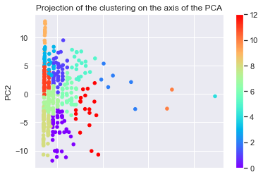

```python
from sklearn.decomposition import PCA

pca = PCA(n_components=2)
data_reduced = pca.fit_transform(X)
data_reduced = pd.DataFrame(data_reduced)

ax = data_reduced.plot(kind='scatter', x=0, y=1, c=preds, cmap='rainbow')
ax.set_xlabel('PC1')
ax.set_ylabel('PC2')
ax.set_title('Projection of the clustering on the axis of the PCA')
```

```python
for n in range (2,30):
    # random_state makes the results reproducible
    # n_jobs=-1 means run with all machine processors
    #Looks like n_jobs is defaulted to use all cores now, so we will remove to get rid of this ugly warning
    model = KMeans(n_clusters=n, random_state=42 )
    model.fit(X)
    # gather the predictions
    preds= model.predict(X)
    score = metrics.silhouette_score(X, preds)
    print('Silhouette score for ',n,' clusters: ',score)
```

```
Silhouette score for  2  clusters:  0.42209431823156734
Silhouette score for  3  clusters:  0.3394734695134711
Silhouette score for  4  clusters:  0.25276599147970397
Silhouette score for  5  clusters:  0.2231951804669021
Silhouette score for  6  clusters:  0.1652943701994924
Silhouette score for  7  clusters:  0.16519786417666815
Silhouette score for  8  clusters:  0.15760085549729622
Silhouette score for  9  clusters:  0.13278603147624848
Silhouette score for  10  clusters:  0.13365734276663413
Silhouette score for  11  clusters:  0.13292138415526694
Silhouette score for  12  clusters:  0.1393770622094747
Silhouette score for  13  clusters:  0.12767015799537987
Silhouette score for  14  clusters:  0.11997525158947846
Silhouette score for  15  clusters:  0.11451487899109687
Silhouette score for  16  clusters:  0.11318621396954952
Silhouette score for  17  clusters:  0.10882478770850627
Silhouette score for  18  clusters:  0.11006680671285829
Silhouette score for  19  clusters:  0.10826234248515464
Silhouette score for  20  clusters:  0.10737692025331733
Silhouette score for  21  clusters:  0.10632462034892456
Silhouette score for  22  clusters:  0.09838863913409718
Silhouette score for  23  clusters:  0.10162674589002149
Silhouette score for  24  clusters:  0.10194708542527331
Silhouette score for  25  clusters:  0.09143433046821624
Silhouette score for  26  clusters:  0.09292515473945777
Silhouette score for  27  clusters:  0.09034010363082175
Silhouette score for  28  clusters:  0.08938173617462963
Silhouette score for  29  clusters:  0.09093317573338854
```

```python
model = KMeans(n_clusters=2, random_state=42)
model.fit(X)
preds= model.predict(X)

score = metrics.silhouette_score(X, preds)
score
```

```
0.42209431823156734
```

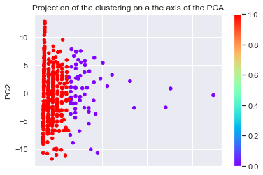

```python
pca = PCA(n_components=2)
data_reduced = pca.fit_transform(X)
data_reduced = pd.DataFrame(data_reduced)

ax = data_reduced.plot(kind='scatter', x=0, y=1, c=preds, cmap='rainbow')
ax.set_xlabel('PC1')
ax.set_ylabel('PC2')
ax.set_title('Projection of the clustering on a the axis of the PCA')
```

## Let's gather our thoughts for a second

So, much like the walkthrough, it does seem as though 2 clusters was the way to go, though the PCA is still less than convincing, and honestly a bit of a let down.

## A theory

Looking at our data quickly, as well as at the correlation plot, we can see that our G1 and G2 Columns appear to be highly correlated to the G3. This makes logical sense, as these are semester 1 and semester 2 grades, while g3 is the final grades, conceivably a combination of the two.

Let's copy our df_encoded dataframe, drop the G1 & G2 columns, then run it again.

```python
df_enc2 = df_encoded.copy()
```

```python
df_enc2
```

|  | age | Medu | Fedu | traveltime | studytime | failures | famrel | freetime | goout | Dalc | ... | activities_no | activities_yes | nursery_no | nursery_yes | higher_no | higher_yes | internet_no | internet_yes | romantic_no | romantic_yes |
| --- | --- | --- | --- | --- | --- | --- | --- | --- | --- | --- | --- | --- | --- | --- | --- | --- | --- | --- | --- | --- | --- |
| 0 | 18 | 4 | 4 | 2 | 2 | 0 | 4 | 3 | 4 | 1 | ... | 1 | 0 | 0 | 1 | 0 | 1 | 1 | 0 | 1 | 0 |
| 1 | 17 | 1 | 1 | 1 | 2 | 0 | 5 | 3 | 3 | 1 | ... | 1 | 0 | 1 | 0 | 0 | 1 | 0 | 1 | 1 | 0 |
| 2 | 15 | 1 | 1 | 1 | 2 | 3 | 4 | 3 | 2 | 2 | ... | 1 | 0 | 0 | 1 | 0 | 1 | 0 | 1 | 1 | 0 |
| 3 | 15 | 4 | 2 | 1 | 3 | 0 | 3 | 2 | 2 | 1 | ... | 0 | 1 | 0 | 1 | 0 | 1 | 0 | 1 | 0 | 1 |
| 4 | 16 | 3 | 3 | 1 | 2 | 0 | 4 | 3 | 2 | 1 | ... | 1 | 0 | 0 | 1 | 0 | 1 | 1 | 0 | 1 | 0 |
| ... | ... | ... | ... | ... | ... | ... | ... | ... | ... | ... | ... | ... | ... | ... | ... | ... | ... | ... | ... | ... | ... |
| 390 | 20 | 2 | 2 | 1 | 2 | 2 | 5 | 5 | 4 | 4 | ... | 1 | 0 | 0 | 1 | 0 | 1 | 1 | 0 | 1 | 0 |
| 391 | 17 | 3 | 1 | 2 | 1 | 0 | 2 | 4 | 5 | 3 | ... | 1 | 0 | 1 | 0 | 0 | 1 | 0 | 1 | 1 | 0 |
| 392 | 21 | 1 | 1 | 1 | 1 | 3 | 5 | 5 | 3 | 3 | ... | 1 | 0 | 1 | 0 | 0 | 1 | 1 | 0 | 1 | 0 |
| 393 | 18 | 3 | 2 | 3 | 1 | 0 | 4 | 4 | 1 | 3 | ... | 1 | 0 | 1 | 0 | 0 | 1 | 0 | 1 | 1 | 0 |
| 394 | 19 | 1 | 1 | 1 | 1 | 0 | 3 | 2 | 3 | 3 | ... | 1 | 0 | 0 | 1 | 0 | 1 | 0 | 1 | 1 | 0 |

395 rows × 59 columns

```python
df_enc2.drop(columns=['G1','G2'], inplace=True)
```

```python
df_enc2
```

|  | age | Medu | Fedu | traveltime | studytime | failures | famrel | freetime | goout | Dalc | ... | activities_no | activities_yes | nursery_no | nursery_yes | higher_no | higher_yes | internet_no | internet_yes | romantic_no | romantic_yes |
| --- | --- | --- | --- | --- | --- | --- | --- | --- | --- | --- | --- | --- | --- | --- | --- | --- | --- | --- | --- | --- | --- |
| 0 | 18 | 4 | 4 | 2 | 2 | 0 | 4 | 3 | 4 | 1 | ... | 1 | 0 | 0 | 1 | 0 | 1 | 1 | 0 | 1 | 0 |
| 1 | 17 | 1 | 1 | 1 | 2 | 0 | 5 | 3 | 3 | 1 | ... | 1 | 0 | 1 | 0 | 0 | 1 | 0 | 1 | 1 | 0 |
| 2 | 15 | 1 | 1 | 1 | 2 | 3 | 4 | 3 | 2 | 2 | ... | 1 | 0 | 0 | 1 | 0 | 1 | 0 | 1 | 1 | 0 |
| 3 | 15 | 4 | 2 | 1 | 3 | 0 | 3 | 2 | 2 | 1 | ... | 0 | 1 | 0 | 1 | 0 | 1 | 0 | 1 | 0 | 1 |
| 4 | 16 | 3 | 3 | 1 | 2 | 0 | 4 | 3 | 2 | 1 | ... | 1 | 0 | 0 | 1 | 0 | 1 | 1 | 0 | 1 | 0 |
| ... | ... | ... | ... | ... | ... | ... | ... | ... | ... | ... | ... | ... | ... | ... | ... | ... | ... | ... | ... | ... | ... |
| 390 | 20 | 2 | 2 | 1 | 2 | 2 | 5 | 5 | 4 | 4 | ... | 1 | 0 | 0 | 1 | 0 | 1 | 1 | 0 | 1 | 0 |
| 391 | 17 | 3 | 1 | 2 | 1 | 0 | 2 | 4 | 5 | 3 | ... | 1 | 0 | 1 | 0 | 0 | 1 | 0 | 1 | 1 | 0 |
| 392 | 21 | 1 | 1 | 1 | 1 | 3 | 5 | 5 | 3 | 3 | ... | 1 | 0 | 1 | 0 | 0 | 1 | 1 | 0 | 1 | 0 |
| 393 | 18 | 3 | 2 | 3 | 1 | 0 | 4 | 4 | 1 | 3 | ... | 1 | 0 | 1 | 0 | 0 | 1 | 0 | 1 | 1 | 0 |
| 394 | 19 | 1 | 1 | 1 | 1 | 0 | 3 | 2 | 3 | 3 | ... | 1 | 0 | 0 | 1 | 0 | 1 | 0 | 1 | 1 | 0 |

395 rows × 57 columns

```python
X = df_enc2.iloc[:,df_enc2.columns != 'G3']
y = df_enc2.iloc[:,df_enc2.columns == 'G3']
```

```python
sum_sq= []


for n in range (2,30):
    print('Calculating for ',n,' clusters')

    # random_start makes the results reproducible
    # n_jobs=-1 means run with all machine processors
    model = KMeans(n_clusters=n, random_state=42)
    model.fit(X)
    sum_sq.append(-model.score(X))
```

```
Calculating for  2  clusters
Calculating for  3  clusters
Calculating for  4  clusters
Calculating for  5  clusters
Calculating for  6  clusters
Calculating for  7  clusters
Calculating for  8  clusters
Calculating for  9  clusters
Calculating for  10  clusters
Calculating for  11  clusters
Calculating for  12  clusters
Calculating for  13  clusters
Calculating for  14  clusters
Calculating for  15  clusters
Calculating for  16  clusters
Calculating for  17  clusters
Calculating for  18  clusters
Calculating for  19  clusters
Calculating for  20  clusters
Calculating for  21  clusters
Calculating for  22  clusters
Calculating for  23  clusters
Calculating for  24  clusters
Calculating for  25  clusters
Calculating for  26  clusters
Calculating for  27  clusters
Calculating for  28  clusters
Calculating for  29  clusters
```

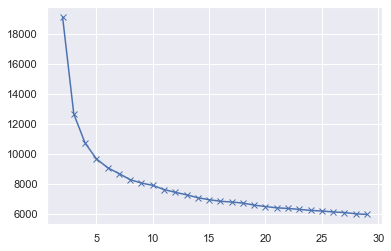

```python
plt.plot(range(2, 30), sum_sq, 'bx-')
```

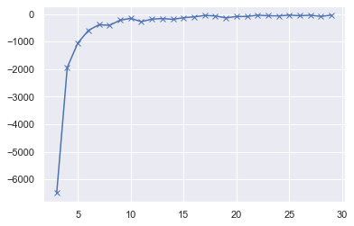

```python
plt.plot(range(3, 30), np.diff(sum_sq), 'bx-')
```

```python
for n in range (2,30):
    # random_state makes the results reproducible
    # n_jobs=-1 means run with all machine processors
    #Looks like n_jobs is defaulted to use all cores now, so we will remove to get rid of this ugly warning
    model = KMeans(n_clusters=n, random_state=42 )
    model.fit(X)
    # gather the predictions
    preds= model.predict(X)
    score = metrics.silhouette_score(X, preds)
    print('Silhouette score for ',n,' clusters: ',score)
```

```
Silhouette score for  2  clusters:  0.5119665918136315
Silhouette score for  3  clusters:  0.4401237106613952
Silhouette score for  4  clusters:  0.21383674649294312
Silhouette score for  5  clusters:  0.18306692899141733
Silhouette score for  6  clusters:  0.17894202482162702
Silhouette score for  7  clusters:  0.12392229650993603
Silhouette score for  8  clusters:  0.10598354151012931
Silhouette score for  9  clusters:  0.09927466335132894
Silhouette score for  10  clusters:  0.0980296977130901
Silhouette score for  11  clusters:  0.08681294106902995
Silhouette score for  12  clusters:  0.08571075360045469
Silhouette score for  13  clusters:  0.08577453960906262
Silhouette score for  14  clusters:  0.08566459222277091
Silhouette score for  15  clusters:  0.08538764262419113
Silhouette score for  16  clusters:  0.08232215717598297
Silhouette score for  17  clusters:  0.0777859368149924
Silhouette score for  18  clusters:  0.07593622748472036
Silhouette score for  19  clusters:  0.0780492919095828
Silhouette score for  20  clusters:  0.07377596491207171
Silhouette score for  21  clusters:  0.06905837674003754
Silhouette score for  22  clusters:  0.07814289952834202
Silhouette score for  23  clusters:  0.07683003284484262
Silhouette score for  24  clusters:  0.06184731800009618
Silhouette score for  25  clusters:  0.05938879795550189
Silhouette score for  26  clusters:  0.05988406051580081
Silhouette score for  27  clusters:  0.05810482116243873
Silhouette score for  28  clusters:  0.06581525672444744
Silhouette score for  29  clusters:  0.0649524150667437
```

```python
model = KMeans(n_clusters=2, random_state=42)
model.fit(X)
preds= model.predict(X)

score = metrics.silhouette_score(X, preds)
score
```

```
0.5119665918136315
```

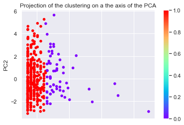

```python
pca = PCA(n_components=2)
data_reduced = pca.fit_transform(X)
data_reduced = pd.DataFrame(data_reduced)

ax = data_reduced.plot(kind='scatter', x=0, y=1, c=preds, cmap='rainbow')
ax.set_xlabel('PC1')
ax.set_ylabel('PC2')
ax.set_title('Projection of the clustering on a the axis of the PCA')
```

## Revisit

I originally submitted this assignment with this as the ending. Below, I'm going to try and implement TPOT to see if we can't do a better job clustering our data, perhaps with a different ML model.

```python
from tpot import TPOTClassifier
from sklearn.datasets import load_digits
from sklearn.model_selection import train_test_split

# Any results you write to the current directory are saved as output.
import timeit
```

```python
X_train, X_test, y_train, y_test = train_test_split(X, y, train_size=0.8, test_size=0.2, random_state=42)
```

```python
%%time
tpot = TPOTClassifier(generations=5, population_size=50, verbosity=2, n_jobs=-1, random_state=42)
tpot.fit(X_train, y_train)
print(tpot.score(X_test, y_test))
```

```
Generation 1 - Current best internal CV score: 0.2470734126984127

Generation 2 - Current best internal CV score: 0.2470734126984127

Generation 3 - Current best internal CV score: 0.2564484126984127

Generation 4 - Current best internal CV score: 0.2564484126984127

Generation 5 - Current best internal CV score: 0.25957341269841266

Best pipeline: RandomForestClassifier(input_matrix, bootstrap=True, criterion=gini, max_features=0.6000000000000001, min_samples_leaf=3, min_samples_split=17, n_estimators=100)
0.1518987341772152
Wall time: 2min 29s
```

```python
from tpot import TPOTRegressor
```

```python
%%time
tpot = TPOTRegressor(generations=5, population_size=50, verbosity=2, n_jobs=-1, scoring='r2', random_state=42)
tpot.fit(X_train, y_train)
print(tpot.score(X_test, y_test))
```

```
Generation 1 - Current best internal CV score: 0.2673513906772262

Generation 2 - Current best internal CV score: 0.28111326765763855

Generation 3 - Current best internal CV score: 0.28111326765763855

Generation 4 - Current best internal CV score: 0.28509114116828316

Generation 5 - Current best internal CV score: 0.28509114116828316

Best pipeline: AdaBoostRegressor(MinMaxScaler(Normalizer(input_matrix, norm=max)), learning_rate=0.1, loss=square, n_estimators=100)
0.1773028586865094
Wall time: 1min 36s
```

## Conclusion

Well, we still didn't get anything good. I've thrown my hands up a couple times at this point with the data set, and I refuse to believe that this was the intention and I know I'm missing something. I'm submitting this on the last Sunday of the class, just to show the continued attempts, but rest assured I will be revisiting this again once I'm less frustrated.